# Red Wine Analysis by R

Edwin

2017-10-30

# 单变量部分

##### 下面显示该数据集的一些统计信息，如平均值、方差、最大、最小值等。

##### 这个数据集包括1599个样本，每个样本有13个特征变量。 quality这个变量分为0到10.共11个级别。0（非常差）和10（非常好）之间.数据类型都为数字型。

```
## 'data.frame':    1599 obs. of  13 variables:
##  $ X                   : int  1 2 3 4 5 6 7 8 9 10 ...
##  $ fixed.acidity       : num  7.4 7.8 7.8 11.2 7.4 7.4 7.9 7.3 7.8 7.5 ...
##  $ volatile.acidity    : num  0.7 0.88 0.76 0.28 0.7 0.66 0.6 0.65 0.58 0.5 ...
##  $ citric.acid         : num  0 0 0.04 0.56 0 0 0.06 0 0.02 0.36 ...
##  $ residual.sugar      : num  1.9 2.6 2.3 1.9 1.9 1.8 1.6 1.2 2 6.1 ...
##  $ chlorides           : num  0.076 0.098 0.092 0.075 0.076 0.075 0.069 0.065 0.073 0.071 ...
##  $ free.sulfur.dioxide : num  11 25 15 17 11 13 15 15 9 17 ...
##  $ total.sulfur.dioxide: num  34 67 54 60 34 40 59 21 18 102 ...
##  $ density             : num  0.998 0.997 0.997 0.998 0.998 ...
##  $ pH                  : num  3.51 3.2 3.26 3.16 3.51 3.51 3.3 3.39 3.36 3.35 ...
##  $ sulphates           : num  0.56 0.68 0.65 0.58 0.56 0.56 0.46 0.47 0.57 0.8 ...
##  $ alcohol             : num  9.4 9.8 9.8 9.8 9.4 9.4 9.4 10 9.5 10.5 ...
##  $ quality             : int  5 5 5 6 5 5 5 7 7 5 ...
```

```
##        X          fixed.acidity   volatile.acidity  citric.acid
##  Min.   :   1.0   Min.   : 4.60   Min.   :0.1200   Min.   :0.000
##  1st Qu.: 400.5   1st Qu.: 7.10   1st Qu.:0.3900   1st Qu.:0.090
##  Median : 800.0   Median : 7.90   Median :0.5200   Median :0.260
##  Mean   : 800.0   Mean   : 8.32   Mean   :0.5278   Mean   :0.271
##  3rd Qu.:1199.5   3rd Qu.: 9.20   3rd Qu.:0.6400   3rd Qu.:0.420
##  Max.   :1599.0   Max.   :15.90   Max.   :1.5800   Max.   :1.000
##  residual.sugar     chlorides       free.sulfur.dioxide
##  Min.   : 0.900   Min.   :0.01200   Min.   : 1.00
##  1st Qu.: 1.900   1st Qu.:0.07000   1st Qu.: 7.00
##  Median : 2.200   Median :0.07900   Median :14.00
##  Mean   : 2.539   Mean   :0.08747   Mean   :15.87
##  3rd Qu.: 2.600   3rd Qu.:0.09000   3rd Qu.:21.00
##  Max.   :15.500   Max.   :0.61100   Max.   :72.00
##  total.sulfur.dioxide    density             pH          sulphates
##  Min.   :  6.00       Min.   :0.9901   Min.   :2.740   Min.   :0.3300
##  1st Qu.: 22.00       1st Qu.:0.9956   1st Qu.:3.210   1st Qu.:0.5500
##  Median : 38.00       Median :0.9968   Median :3.310   Median :0.6200
##  Mean   : 46.47       Mean   :0.9967   Mean   :3.311   Mean   :0.6581
##  3rd Qu.: 62.00       3rd Qu.:0.9978   3rd Qu.:3.400   3rd Qu.:0.7300
##  Max.   :289.00       Max.   :1.0037   Max.   :4.010   Max.   :2.0000
##     alcohol         quality
##  Min.   : 8.40   Min.   :3.000
##  1st Qu.: 9.50   1st Qu.:5.000
##  Median :10.20   Median :6.000
##  Mean   :10.42   Mean   :5.636
##  3rd Qu.:11.10   3rd Qu.:6.000
##  Max.   :14.90   Max.   :8.000
```

### 单变量图表部分

##### 葡萄酒的品质分布并不均匀，普通品质的葡萄酒占大多数，品质高的和差的葡萄酒占少数.

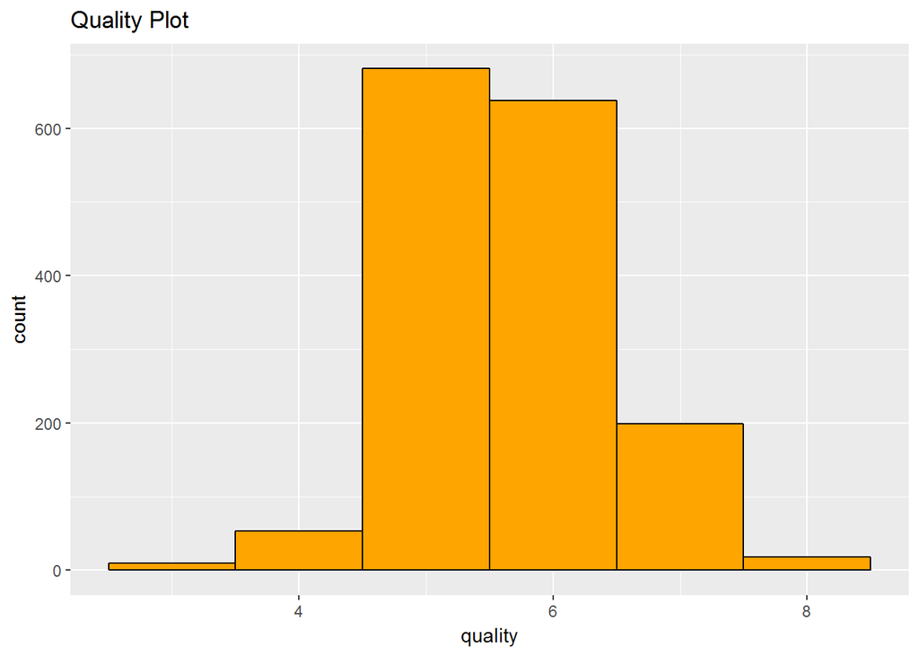

##### 固定酸度的均值在8左右，但有一些离群值。

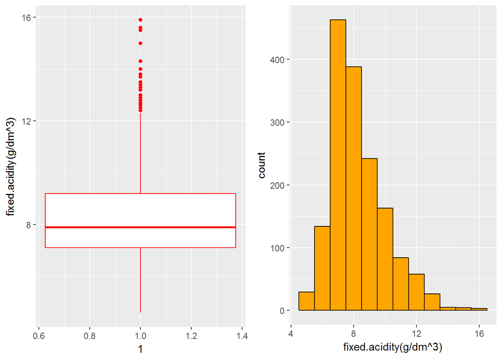

##### 酒精度基本都在14以下。有少量的离群值。最大约为14.8

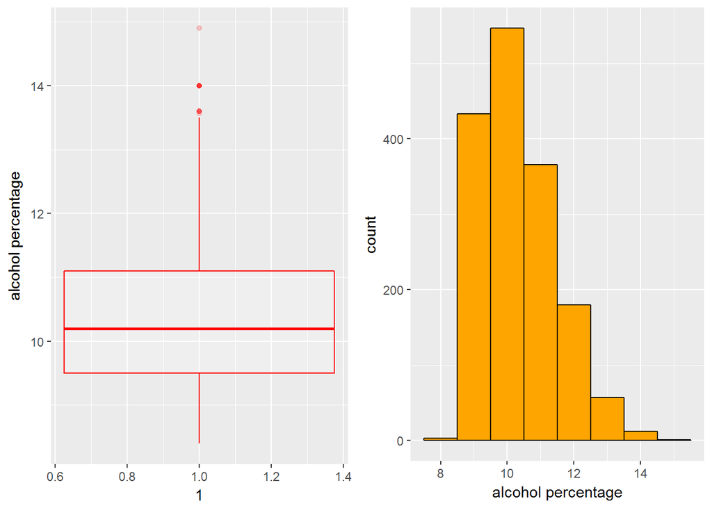

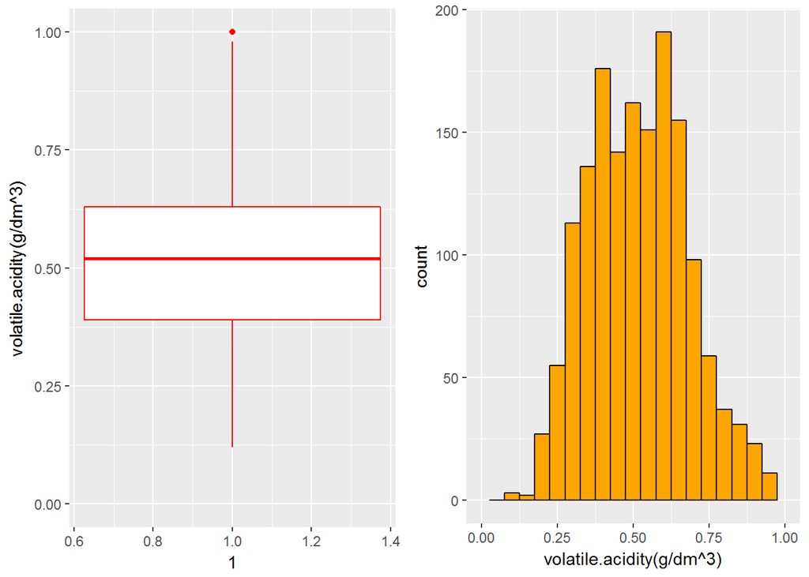

##### 柠檬酸的分布. 发现一些数据为0，从CSV文件中也能看到一些为0的值。估计数据采集不完整

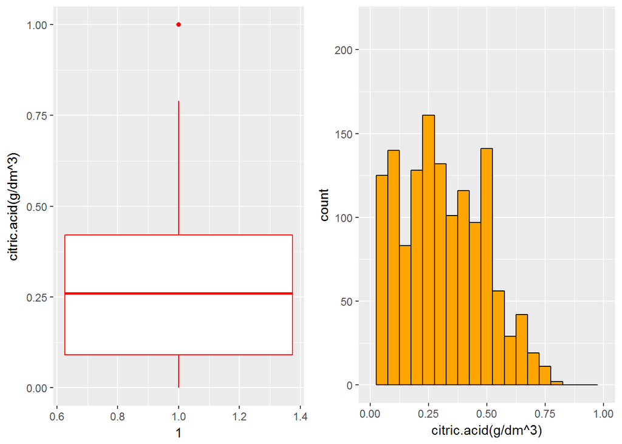

##### 剩余糖分的统计图. 有很多的离群值。分布也很不均匀

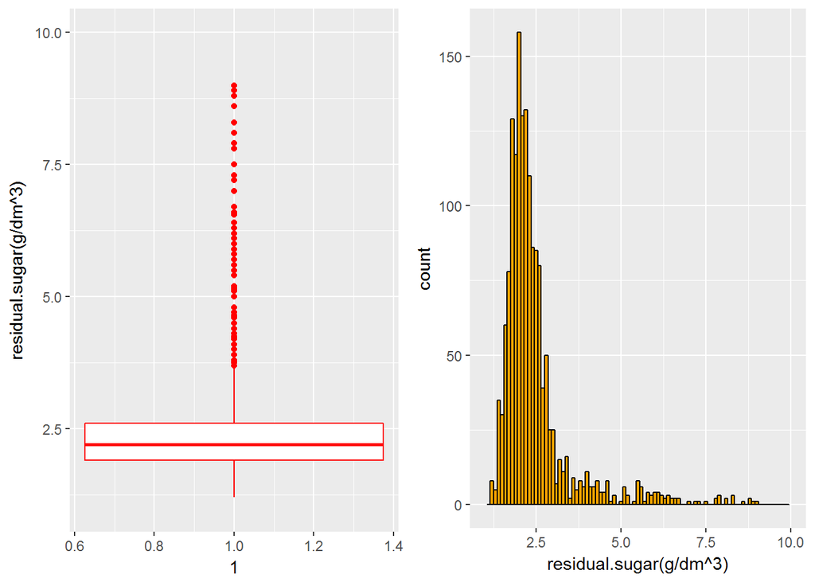

##### 氯化物统计图. 同样有有很多的离群值。

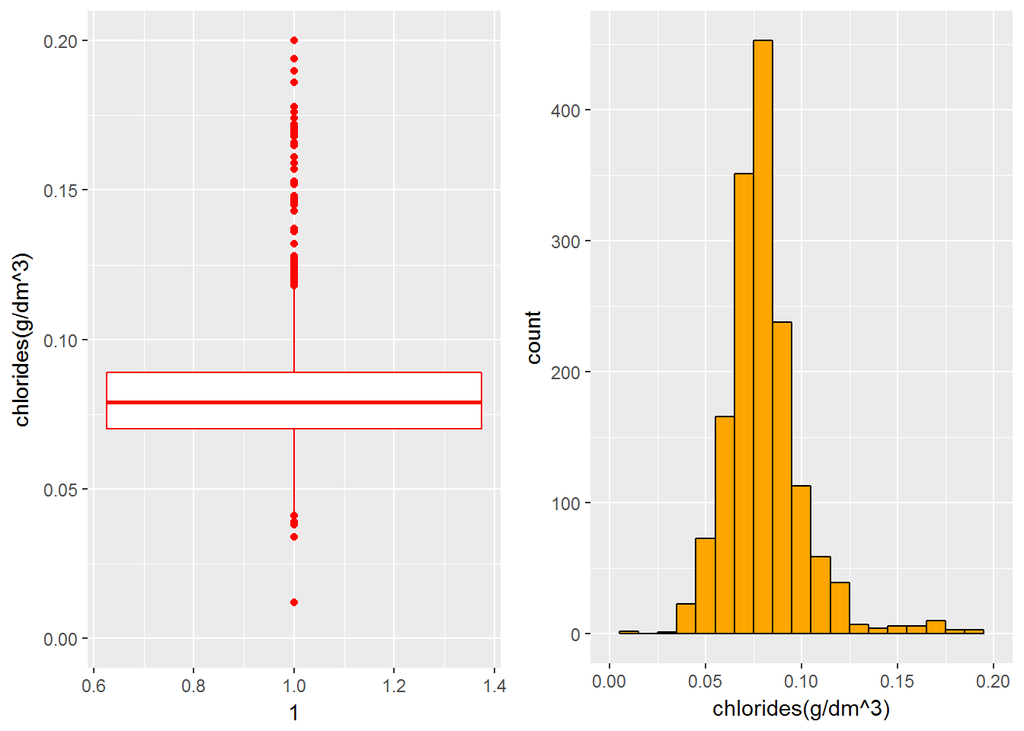

##### 游离二氧化硫的统计图。数据分布不均匀。

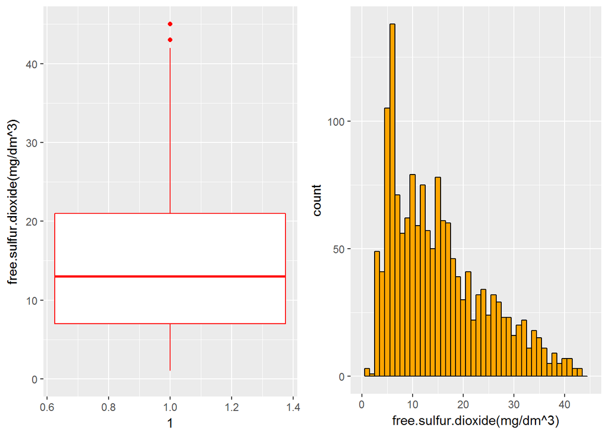

##### 密度的统计图. 类似一个正态分布

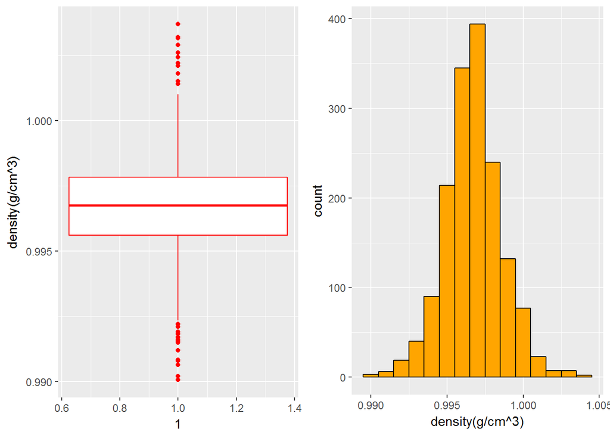

##### 总二氧化硫统计图 和游离二氧化硫（free.sulfur.dioxide）的分布差不多，也有较多的离群值。

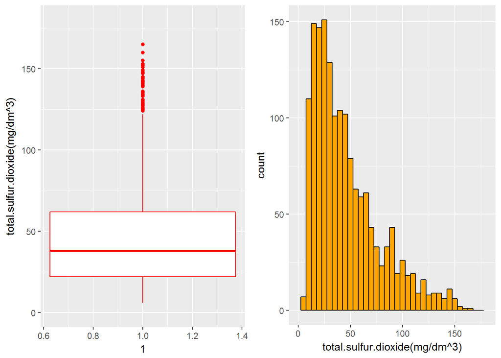

##### 硫酸盐的统计图 存在较多的离群值。数据分布不均匀。

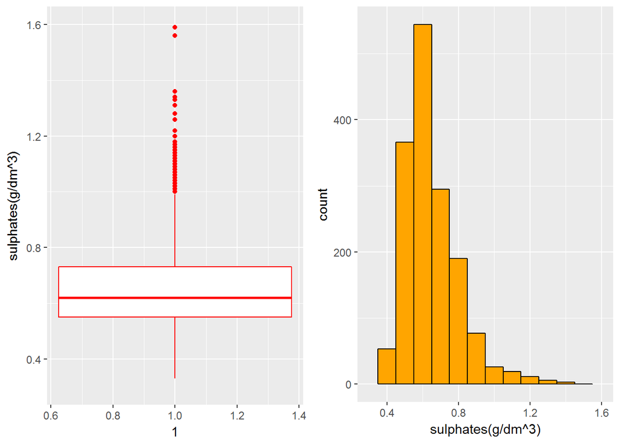

##### PH值的分布类似一个正态分布

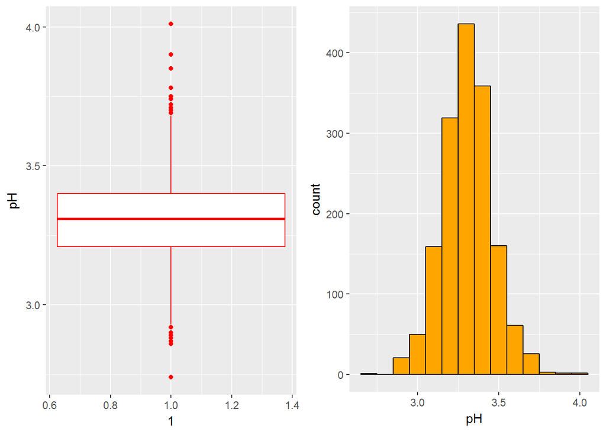

# 单变量分析

### What is the structure of your dataset?

#### density的均值0.9968，最大值是1。0037. 密度的变化不是很大

#### 每个特征变量的解释

#### 1 - fixed acidity: most acids involved with wine or fixed or nonvolatile (do not evaporate readily)

#### 固定的酸度:与葡萄酒或固定或不挥发性有关的大多数酸(不容易挥发)

#### 2 - volatile acidity: the amount of acetic acid in wine, which at too high of levels can lead to an unpleasant, vinegar taste

#### 葡萄酒中醋酸的含量过高会导致不愉快的醋味

#### 3 - citric acid: found in small quantities, citric acid can add ‘freshness’ and flavor to wines

#### 少量的柠檬酸可以给葡萄酒添加新鲜感和风味

#### 4 - residual sugar: the amount of sugar remaining after fermentation stops, it’s rare to find wines with less than 1 gram/liter and wines with greater than 45 grams/liter are considered sweet

#### 剩余糖分:发酵后残留的糖量，很少能发现含有少于1克/升的葡萄酒和大于45克/升的葡萄酒被认为是甜的

#### 5 - chlorides: the amount of salt in the wine

#### 氯化物:葡萄酒中的盐含量

#### 6 - free sulfur dioxide: the free form of SO2 exists in equilibrium between molecular SO2 (as a dissolved gas) and bisulfite ion; it prevents microbial growth and the oxidation of wine

#### 游离二氧化硫:SO2的自由形式存在于分子SO2(as a溶解气体)和bisulfite离子之间的平衡;它可以防止微生物的生长和葡萄酒的氧化

#### 7 - total sulfur dioxide: amount of free and bound forms of S02; in low concentrations, SO2 is mostly undetectable in wine, but at free SO2 concentrations over 50 ppm, SO2 becomes evident in the nose and taste of wine

#### 总二氧化硫:S02的自由和束缚形式;在低浓度下，SO2在葡萄酒中是无法检测的，但在自由SO2浓度超过50ppm的情况下，SO2在鼻子和葡萄酒的味道中变得明显

#### 8 - density: the density of water is close to that of water depending on the percent alcohol and sugar content

#### 密度:水的密度与水的密度接近，这取决于酒精和糖的含量

#### 9 - pH: describes how acidic or basic a wine is on a scale from 0 (very acidic) to 14 (very basic); most wines are between 3-4 on the pH scale

#### 描述一种葡萄酒的酸性或碱性从0(非常酸)到14(非常基本);大多数葡萄酒的pH值在3 - 4之间

#### 10 - sulphates: a wine additive which can contribute to sulfur dioxide gas (S02) levels, wich acts as an antimicrobial and antioxidant

#### 硫酸盐:一种能促进二氧化硫(S02)水平的葡萄酒添加剂，它是一种抗菌剂和抗氧化剂

#### 11 - alcohol: the percent alcohol content of the wine

#### 酒精:酒的酒精含量百分比

### 特征变量的相关性分析

##### 整个数据集变量两两之间的的相关性预览。从结果中可以初步看出如下几个相关性较强的特征，包含正相关或负相关。注：相关系数：两组不同数据的相关程度，取值范围[-1，1]，越接近0越不相关。

```r
cor_data <- cor(
  redwine
)
pandoc.table(cor_data)
```

```
##
## -------------------------------------------------------------------------
##           &nbsp;                X       fixed.acidity   volatile.acidity
## -------------------------- ----------- --------------- ------------------
##           **X**                 1          -0.2685         -0.008815
##
##     **fixed.acidity**        -0.2685          1             -0.2561
##
##    **volatile.acidity**     -0.008815      -0.2561             1
##
##      **citric.acid**         -0.1536       0.6717           -0.5525
##
##     **residual.sugar**      -0.03126       0.1148           0.001918
##
##       **chlorides**          -0.1199       0.09371           0.0613
##
##  **free.sulfur.dioxide**     0.09048       -0.1538          -0.0105
##
##  **total.sulfur.dioxide**    -0.1178       -0.1132          0.07647
##
##        **density**           -0.3684        0.668           0.02203
##
##           **pH**              0.136        -0.683            0.2349
##
##       **sulphates**          -0.1253        0.183            -0.261
##
##        **alcohol**           0.2451       -0.06167          -0.2023
##
##        **quality**           0.06645       0.1241           -0.3906
## -------------------------------------------------------------------------
##
## Table: Table continues below
##
##
## ---------------------------------------------------------------------
##           &nbsp;            citric.acid   residual.sugar   chlorides
## -------------------------- ------------- ---------------- -----------
##           **X**               -0.1536        -0.03126       -0.1199
##
##     **fixed.acidity**         0.6717          0.1148        0.09371
```

[output cut: 74 more lines]

```
##
##  **free.sulfur.dioxide**    -0.02195   0.07038     0.05166    -0.06941   -0.05066
##
##  **total.sulfur.dioxide**   0.07127    -0.06649    0.04295    -0.2057    -0.1851
##
##        **density**             1       -0.3417     0.1485     -0.4962    -0.1749
##
##           **pH**            -0.3417       1        -0.1966     0.2056    -0.05773
##
##       **sulphates**          0.1485    -0.1966        1       0.09359     0.2514
##
##        **alcohol**          -0.4962     0.2056     0.09359       1        0.4762
##
##        **quality**          -0.1749    -0.05773    0.2514      0.4762       1
## ----------------------------------------------------------------------------------
```

### What is/are the main feature(s) of interest in your dataset?

### 确定关键特征变量

#### 从前面初步分析，在这个数据集中，有如下几个重要的特征变量：

#### 1. quality 代表葡萄酒的品质

#### 2. alcohol 代表酒精含量

#### 3. fixed.acidity 代表固定酸度含量

#### 4. citric.acid 代表柠檬酸的含量

#### 5. PH 代表酸碱值

#### 6. volatile.acidity 代表醋酸的含量

#### 7. density 代表密度值

### What other features in the dataset do you think will help support your investigation into your feature(s) of interest?

#### 1. free.sulfur.dioxide和 total.sulfur.dioxide 之间相关性强，这个显而易见，total.sulfur.dioxide中包含free.sulfur.dioxide的含量。所以当free.sulfur.dioxide含量增加时，总的含量自然也会增加，

#### 2. PH值与fixed.acidity、citric.acid、density有较强的相关性。需要在后面的双变量逐个分析。

#### 3. density 与fixed.acidity有很强的相关性（相关系数为0.668）

### Did you create any new variables from existing variables in the dataset?

#### 暂时没有创建新的特征变量。

### Of the features you investigated, were there any unusual distributions? Did you perform any operations on the data to tidy, adjust, or change the form of the data? If so, why did you do this?

#### 通过观察各个特征变量的箱线图，发现residual.sugar、chlorides、sulphates有大量的离群值存在。

#### Citric acid 存在很多0值。估计是收集数据时丢失该值或者本身就是错误的数据

#### 暂未对这些数据进行处理

# 双变量部分

### 根据单变量分析确定的7个重要的特征变量，先分析一下其中6个与葡萄酒品质之间的关系图：

##### 下图显示的是alcohol（酒精）含量和品质的箱线图，从图中可以看出，葡萄酒的品质随着酒精度的增加而提升。（相关系数为0.4762 ）

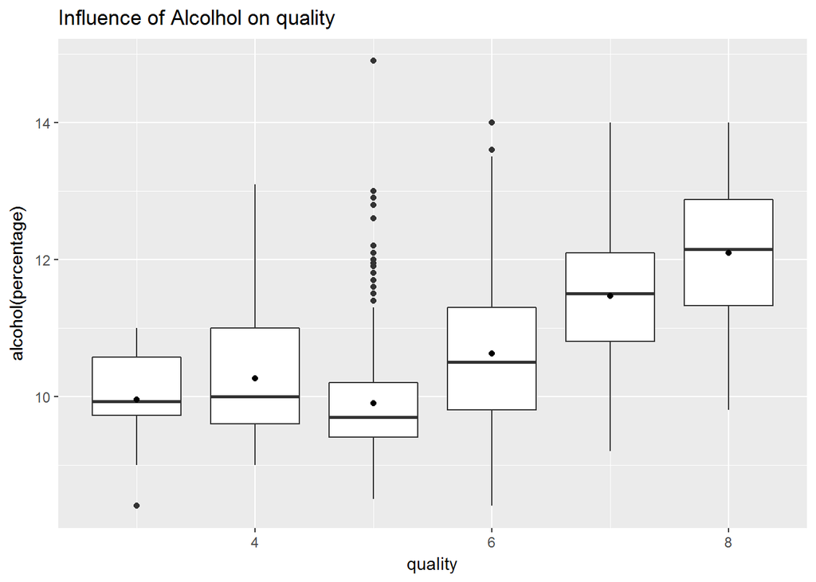

##### 下图显示的是citric.acid（柠檬酸）的含量与品质的箱线图，从图中可以看出，葡萄酒的品质随着citric.acid的增加而提升。（相关系数为0.2264）

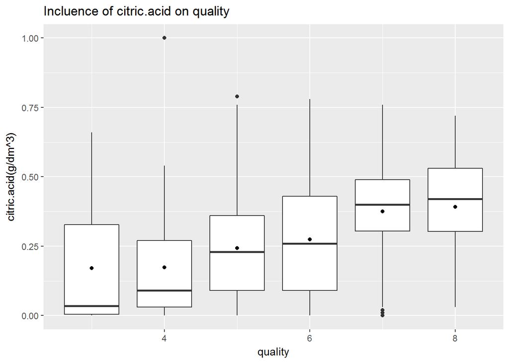

##### 下图显示的是volatile.acidity（醋酸）的含量与品质的箱线图，从图中可以看出，葡萄酒的品质随着volatile.acidity的增加而降低。说明对葡萄酒的品质有负面的影响。从相关性分析也能看出，这两个特征变量的相关系数是负的（-0.3906）。

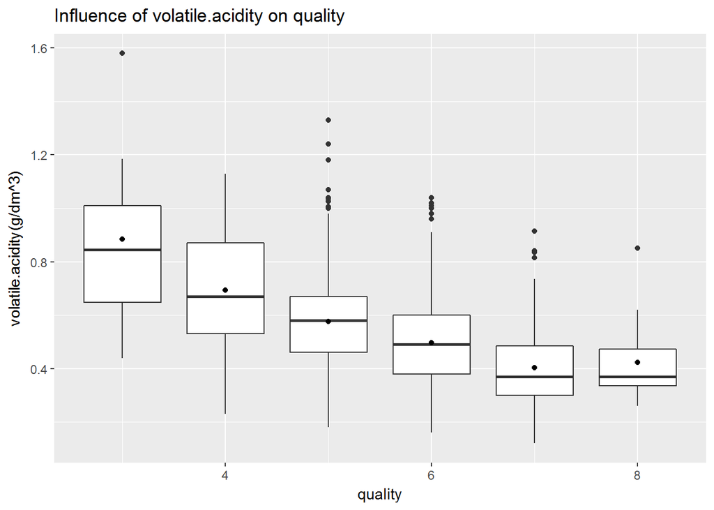

##### 下面显示的是fixed.acidity（固定的酸度）的含量与品质的箱线图，从图中可以看出，他们之间的相关性低，随着fixed.acidity的增加，品质提升不大。（相关性系数为0.1241）

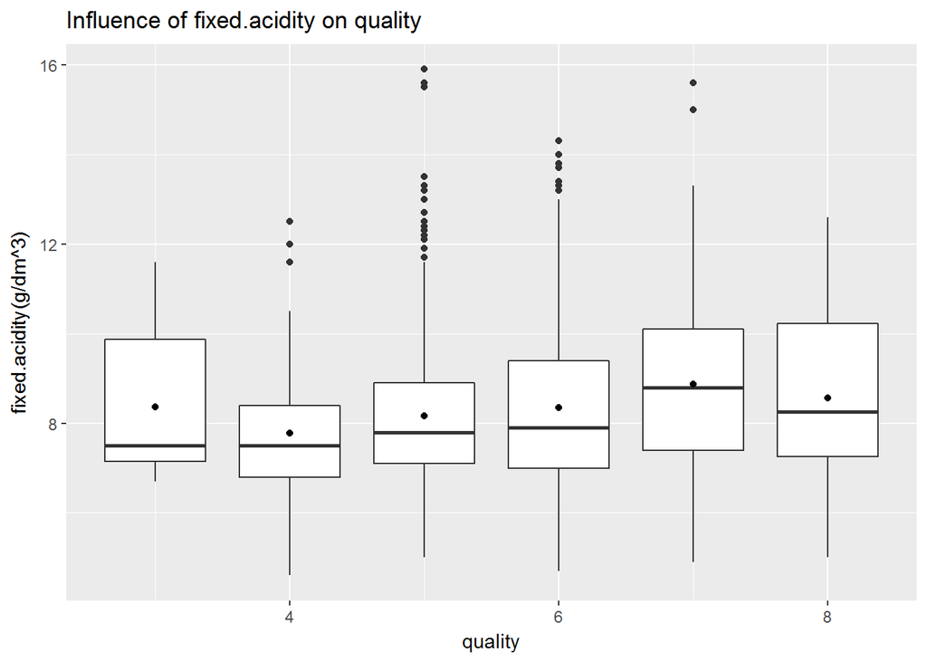

##### 下面显示的是sulphates（硫酸盐）的含量与品质的箱线图，品质好的葡萄酒有高的sulphates值。（相关性系数为0.2514）

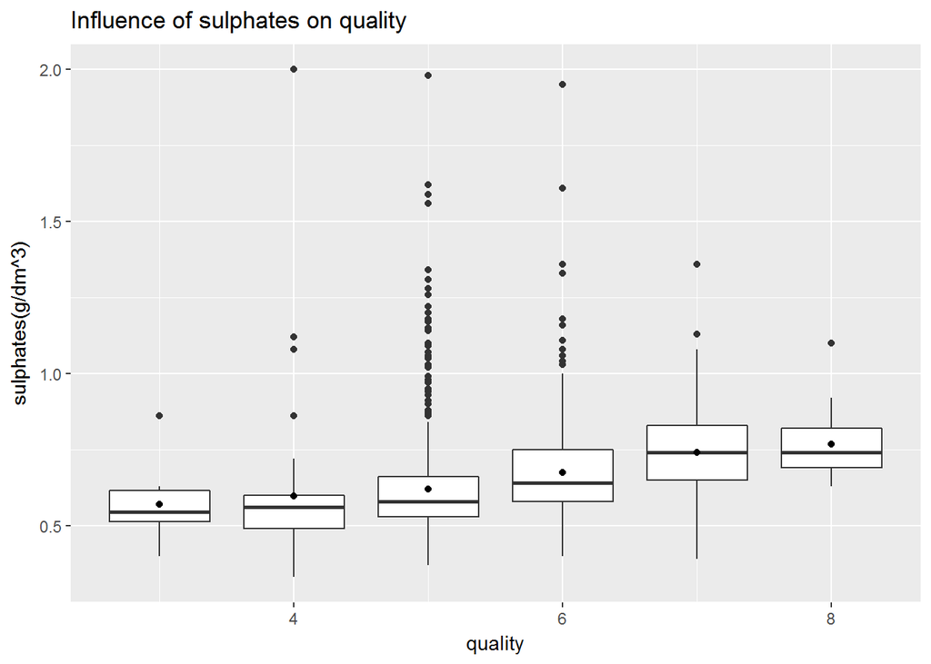

##### 下面显示的是density（密度）的含量与品质的箱线图，从图中可以看出，品质好的有低的密度，可能是由于较高的酒精度所导致。（相关性系数为-0.1749）

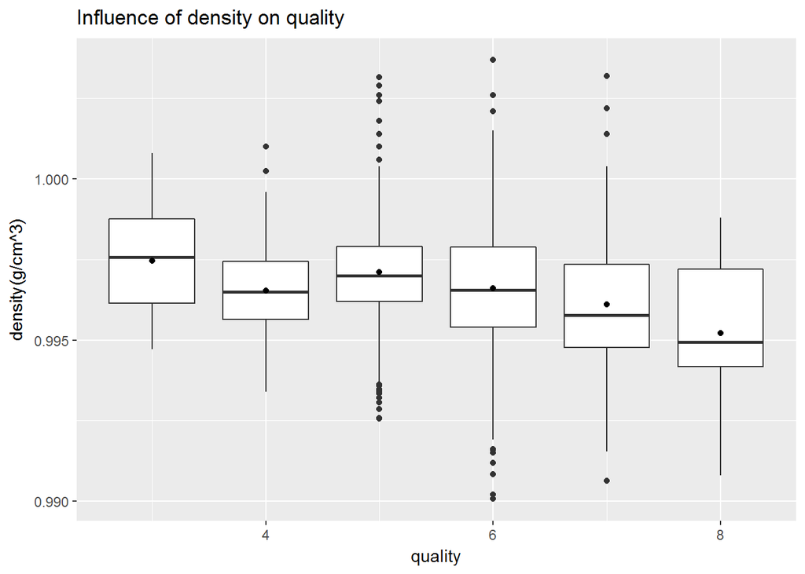

##### 下面显示的是PH（酸碱值）的含量与品质的箱线图，品质高的葡萄酒的PH值低。（相关性系数为-0.05773）

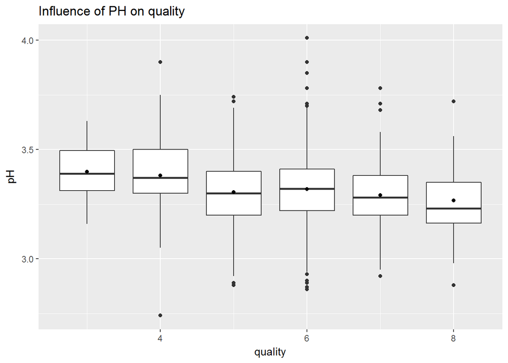

##### 下面显示的是 density（密度） 与fixed.acidity（固定酸度） 的箱线图，随着固定酸度的增加，密度也会增加。（相关性系数为0.668）。这也说明，fixed.acidity对品质影响不大，因为品质好的葡萄酒有低的密度，

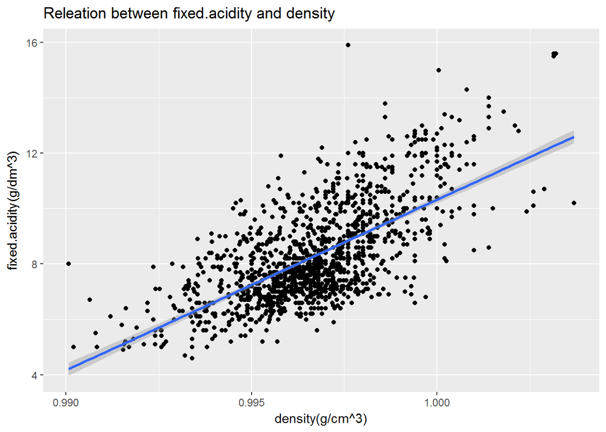

##### 下面显示的是 density（密度） 与alcohol（酒精度） 的箱线图，随着alcohol的增加，密度会减少。（相关性系数为-0.4962）。这也说明，alcohol对品质影响大，因为品质好的葡萄酒有较高的酒精度。这和前面的分析是一致的。

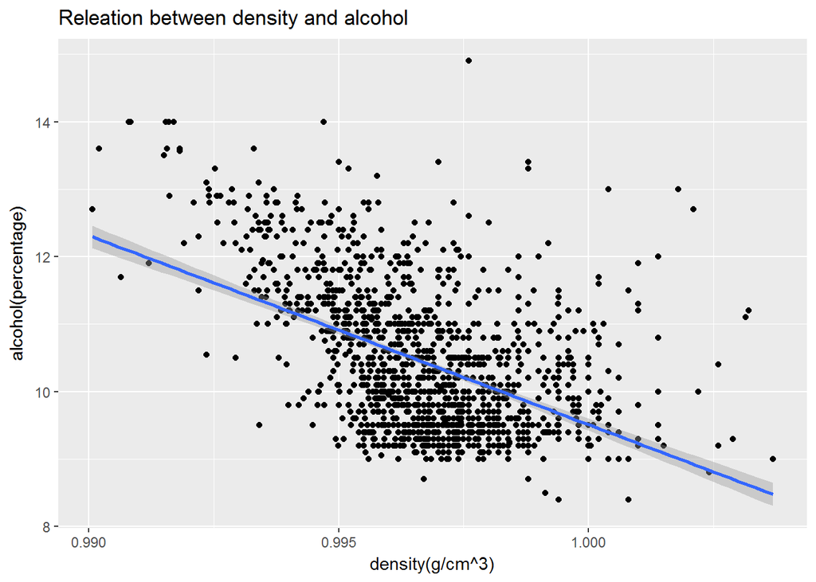

### 下面分析一下PH值与各种酸度之间的关系图。因为化学知识告诉我们，PH值代表的就是酸碱值，所以有必要看一下它们之间的关系。

##### 下图显示fixed.acidity（固定酸度）与PH值之间的趋势关系图。可以看出随着固定酸度的增加，PH变小，

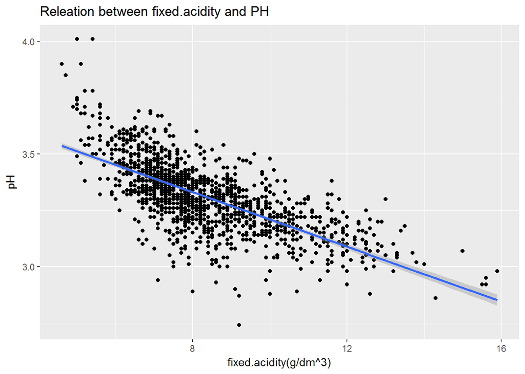

##### 下图显示citric.acid（柠檬酸）与PH值之间的趋势关系图。可以看出随着citric.acid的增加，PH变小，

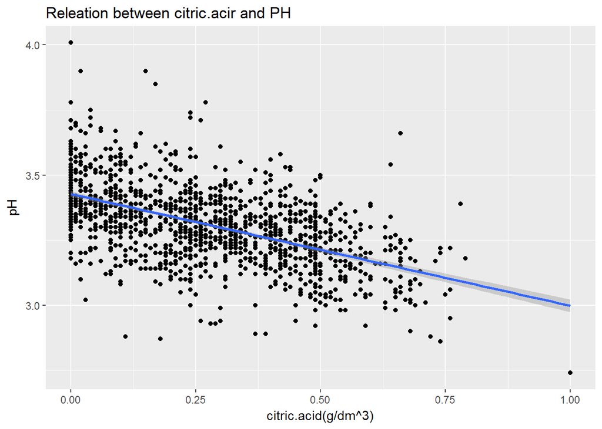

##### 下图显示volatile.acidity（醋酸）与PH值之间的趋势关系图。可以看出随着volatile.acidity的增加，PH却反而变大，由于醋酸是葡萄酒中唯一具有挥发性的有机酸，正是由于这种特性导致PH反而变大。

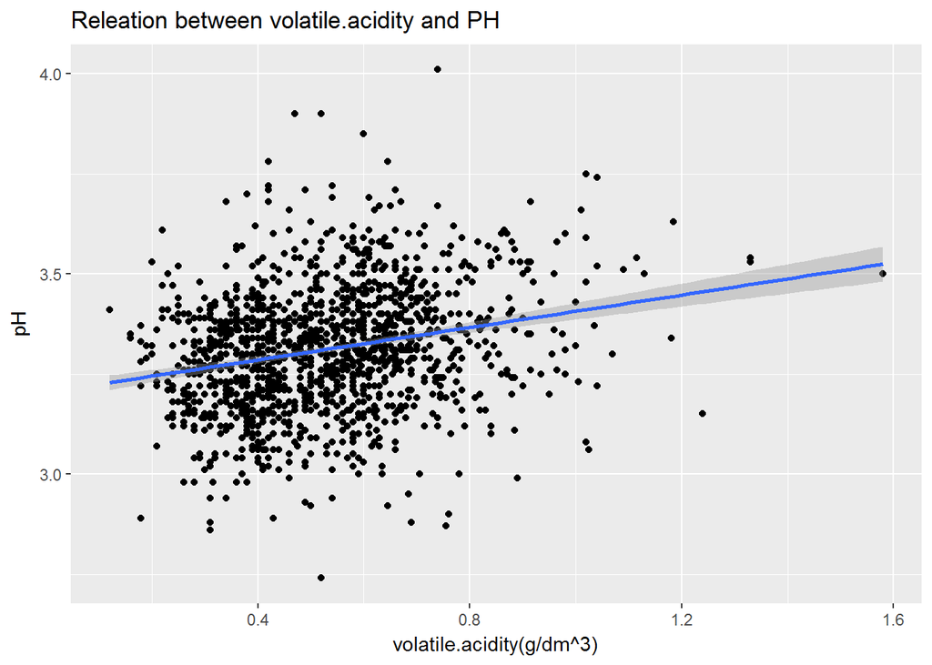

# 双变量分析

### Talk about some of the relationships you observed in this part of the investigation. How did the feature(s) of interest vary with other features in the dataset?

#### 影响葡萄酒品质的特征变量有如下：

#### 1 alcohol（酒精度）

#### 2 volatile.acidity（醋酸）

#### 3 citric.acid（柠檬酸）

#### 4 sulphates（硫酸盐）

#### 更好的葡萄酒似乎有更高的酒精含量。但是还会受到其他因素的影响，比如醋酸的含量。

#### 更好的葡萄酒似乎有较低的密度。可能是由于它们含有较高的酒精含量。

#### 更好的葡萄酒似乎更酸。

### Did you observe any interesting relationships between the other features (not the main feature(s) of interest)?

#### 醋酸特性 醋酸的含量变大时，PH值反而也会变大，这是由于醋酸是葡萄酒中唯一具有挥发性的有机酸，对PH值有逆转的作用，这一点从趋势图中也得到验证。

### What was the strongest relationship you found?

#### 2. 葡萄酒的品质和alcohol有最强的相关性，（相关系数为0.4762）

# 多变量部分

#### 下面显示醋酸、酒精度和葡萄酒的品质之间的关系。说明醋酸起到反作用，挥发性酸浓度越低，酒精浓度越高，葡萄酒就越好。

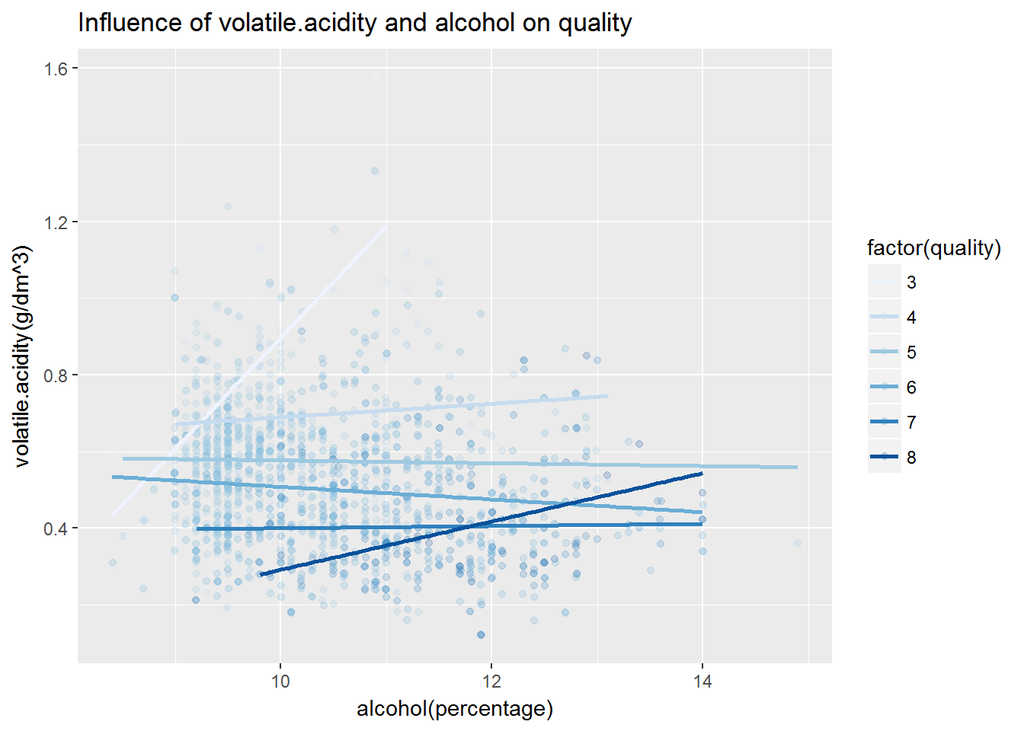

#### 下面显示醋酸、柠檬酸和葡萄酒的品质之间的关系。说明醋酸浓度越低，柠檬酸浓度越高，葡萄酒就越好。

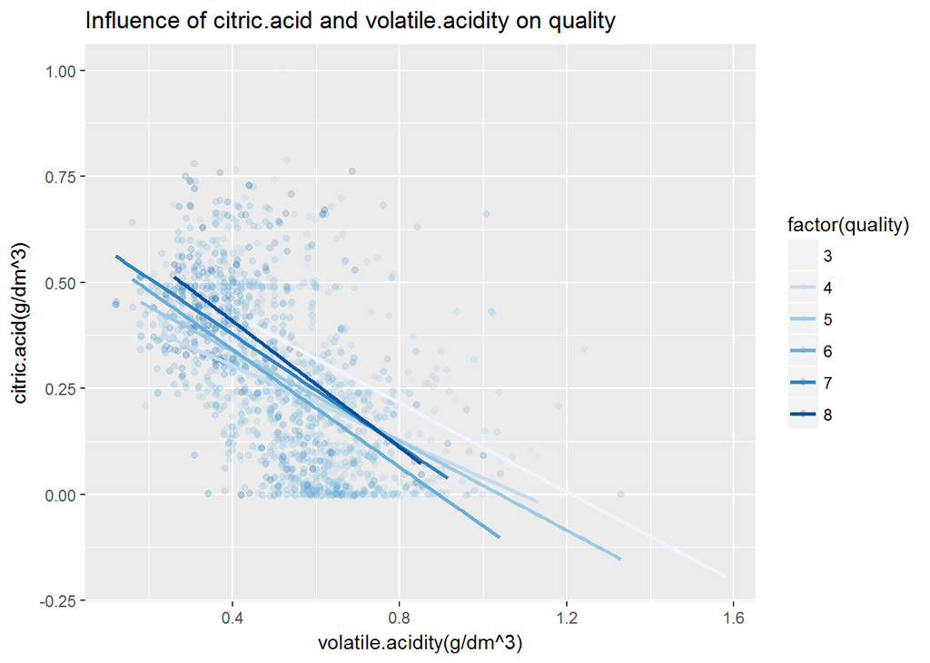

#### 下面显示硫酸盐、酒精度和葡萄酒的品质之间的关系。说明硫酸盐含量高，酒精浓度越高，葡萄酒就越好。

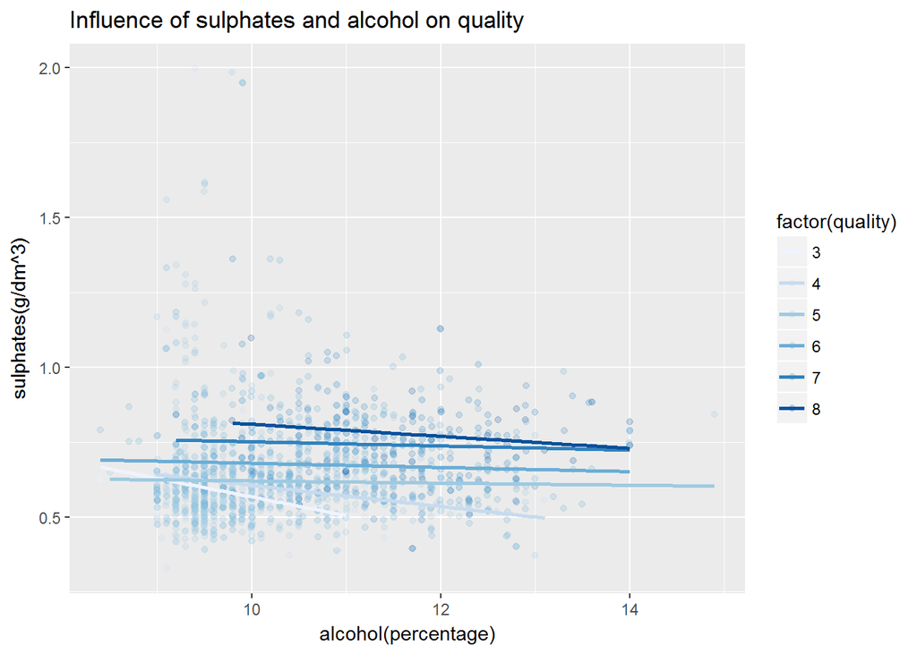

# 多变量分析

### Talk about some of the relationships you observed in this part of the investigation. Were there features that strengthened each other in terms of looking at your feature(s) of interest?

#### 1. 酒精含量高和硫酸盐的含量似乎能产生更好的葡萄酒。

#### 2. 柠檬酸虽然弱相关，但在提高葡萄酒质量方面起着重要作用。

### Were there any interesting or surprising interactions between features?

#### 同样都是酸，柠檬酸和醋酸的作用却相反，醋酸浓度越低，柠檬酸浓度越高，葡萄酒就越好。

# 总结及图表

#### 第一张图

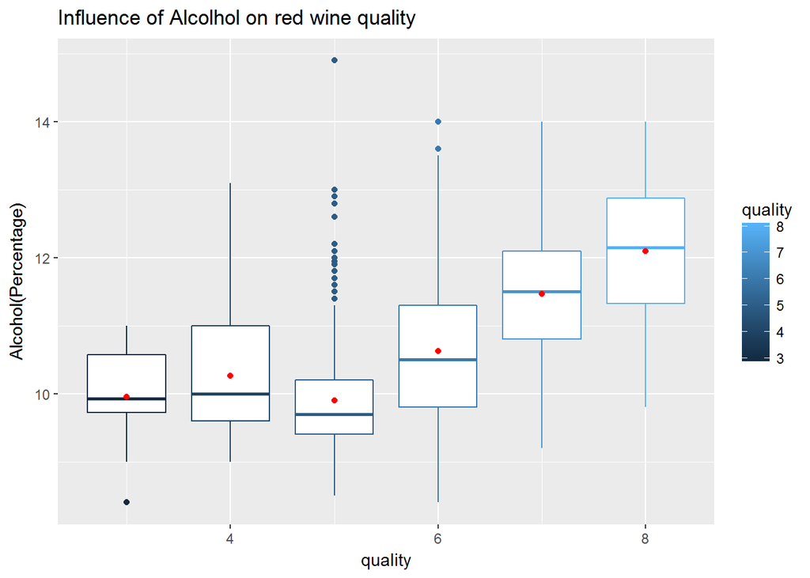

##### 上面是alcohol（酒精）含量和品质的箱线图，从图中可以看出，葡萄酒的品质随着酒精度的增加而提升。（相关系数为0.4762 ），酒精的含量起到了很大的作用，但从前面的分析来看，这并不是影响酒的品质的唯一因素。

#### 第二张图

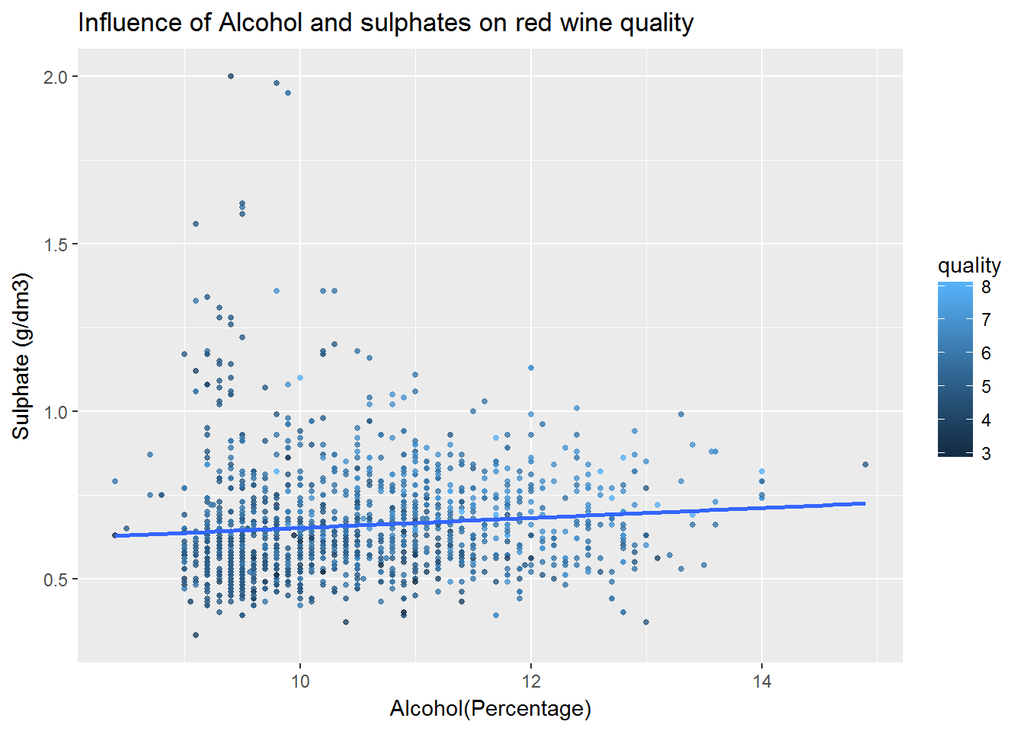

##### 上面显示硫酸盐、酒精度和葡萄酒的品质之间的关系。可以看出好的葡萄酒对酒精含量和硫酸盐浓度都有很高的要求，这意味着高酒精含量和高硫酸盐浓度会产生更好的葡萄酒。

#### 第三张图

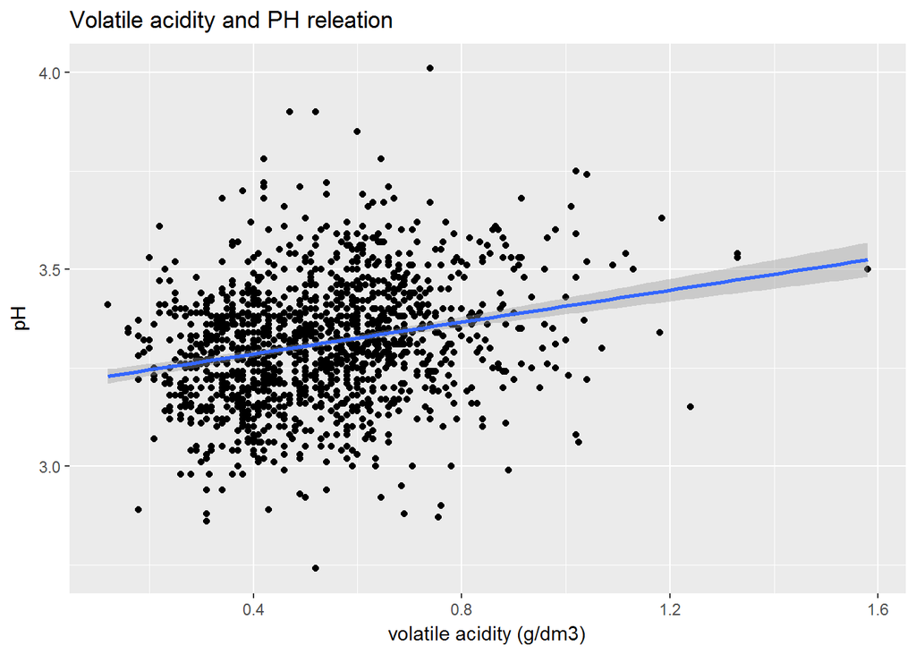

##### 上面显示volatile.acidity（醋酸）与PH值之间的趋势关系图。可以看出随着volatile.acidity的增加，PH却反而变大，由于醋酸是葡萄酒中唯一具有挥发性的有机酸，正是由于这种特性导致PH反而变大。

# 反思

#### 首先确定分析的目标，就是要看哪些特征变量会影响红葡萄酒的品质。第一步先分析了单个不同变量与品质之间的关系，观察每个特征对品质的影响，最终选择酒精度、硫酸盐、柠檬酸和醋酸四个特征值。 然后又分析了PH值和各种酸之间的关系，发现醋酸具有反向逆转的特性，这和它是挥发性酸的特性有关。接着又分析了多个变量之间的关系，发现密度对品质的影响不是很大，醋酸对品质有反向影响。柠檬酸虽然相关系数不大，属于弱相关，但是对品质影响还是比较大的，所以最后确定对红酒品质影响的三个特征变量：酒精含量、柠檬酸含量以及硫酸盐的含量。这些值越高，越能酿出高品质的红葡萄酒。

#### 对于数据集，我觉得还应该加上红酒的外观特征作为变量，用于进一步的分析，比如香气、颜色、口味等。这些感官上的特征也会对定位红酒的品质起到作用。